# Data Camp Python Import and Clean Data Notes

davegoblue

August 1, 2017

## Background and Overview

DataCamp offer interactive courses related to Python Programming. Since R Markdown documents can run simple Python code chunks (though the data is not accessible to future chunks, a large difference from R Markdown for R), this document attempts to summarize notes from the modules when possible.

Topic areas summarized include:

- Python Programming (Introduction, Intermediate, Toolbox I/II, Network Analysis I/II)
- Python Import and Clean Data (Import I/II, Clean)
- Python Data Manipulation (pandas Foundations, Manipulating DF with pandas, Merging DF with pandas, Databases in pandas, Data Types)

This document contains the “Import and Clean Data” components. A separate file DataCamp_Python_Programming_v002 contains the “Programming” components. A separate file DataCamp_PythonNotes_v002 is the evolving working version.

## Python Import and Clean Data

### *Importing Data in Python (Part I)*

Chapter 1 - Introduction and flat files

Welcome to the course - importing from 1) flat files, 2) other native data, and 3) relational databases:

- Begin by looking at text files - plain text and table data (each row is an observation)
- The python “open()” function is the easiest way to look at a file
  - filename = “myFile” ; fPointer = open(filename, mode=“r”), fText = fPointer.read(); file.close()
  - print(fText) # All the text will be printed to the console
- Alternately, can use “with open(”myFile“, mode=”r“) as fPointer: # the file will close when the with ends
  - The “with” statement is known as a context manager
  - The use of a context manager is a best practice, since you never have to worry about closing a file

The importance of flat files in data science:

- Flat files are text files containing records (which is to say “table data” with each row being an observation and each column being an attribute)
- Flat files may also have a header describing the columns of the data (important to know for the data import process)
- Flat files are especially relevant for data science since they are a nice way to store tidy data
- Flat files may be separated by delimitors (comma, tab, etc.)
- Imports may be done through numpy or pandas

Importing flat files using numpy (only for data that is purely numerical):

- numpy arrays are the Python standard for storing numerical data; efficient, fast, and clean, and also often essential for other packages
- numpy.loadtxt() - import numpy as np; myData=np.loadtxt(“myFile”, delimiter=, skiprows=0, usecols=myList, dtype=) # default delimiter is any whitespace, default skip-rows is 0, default usecols is ALL, dtype=str will load as strings
  - Tends to break down when loading mixed data types; these are typically better for pandas
- numpy.genfromtxt() is another option, though only briefly mentioned in this course

Importing flat files using pandas - create 2-D data structures with columns of different data types:

- The pandas package is designed to help elevate Python from data munging (where it has always been excellent) to the full data analysis workflow (which might otherwise require R)
- The pandas DataFrame is modeled off the data frame in R; same idea of observations (rows) and variables (columns)
- The pandas package is the current best practice for loading data from flat files in to Python
- In the most basic usage, myData = pd.read_csv(“myFile”) # assumes import pandas as pd called previously
  - myData.head() # shows the first 5 rows of the data
  - myData.values # This will be the associated numpy array

Example code includes:

```python
# put in directory ./PythonInputFiles/
# moby_dick.txt (converted to romeo-full.txt)
# digits.csv (using mnist_test.csv)
# digits_header.txt (skipped)
# seaslug.txt (downloaded)
# titanic.csv (converted from R)
# titanic_corrupt.txt (skipped)

myPath = "./PythonInputFiles/"


# NEED FILE "moby_dick.txt" (used "romeo-full.txt" instead)
# Open a file: file
file = open(myPath + "romeo-full.txt", mode="r")

# Print it
print(file.read())

# Check whether file is closed
print(file.closed)

# Close file
file.close()

# Check whether file is closed
print(file.closed)


# Read & print the first 3 lines
with open(myPath + "romeo-full.txt") as file:
    print(file.readline())
    print(file.readline())
    print(file.readline())


# NEED DIGIT RECOGNITION SITE - see http://yann.lecun.com/exdb/mnist/
# Import package
import numpy as np

# Assign filename to variable: file
file = myPath + 'mnist_test.csv'

# Load file as array: digits
digits = np.loadtxt(file, delimiter=",")

# Print datatype of digits
print(type(digits))

# Select and reshape a row
im = digits[21, 1:]
im_sq = np.reshape(im, (28, 28))


import matplotlib.pyplot as plt  # so the plotting below can be done

# Plot reshaped data (matplotlib.pyplot already loaded as plt)
plt.imshow(im_sq, cmap='Greys', interpolation='nearest')
# plt.show()
plt.savefig("_dummyPy042.png", bbox_inches="tight")
plt.clf()

# File should be tab-delimited and with a header row (for the skiprows=1)
# Assign the filename: file
# file = 'digits_header.txt'

# Load the data: data
# data = np.loadtxt(file, delimiter="\t", skiprows=1, usecols=[0, 2])

# Print data
# print(data)


# NEED FILE FROM http://www.stat.ucla.edu/projects/datasets/seaslug-explanation.html
# Should be floats with a single text header row, and tab-delimited

# Assign filename: file
file = myPath + 'seaslug.txt'

# Import file: data
data = np.loadtxt(file, delimiter='\t', dtype=str)

# Print the first element of data
print(data[0])

# Import data as floats and skip the first row: data_float
data_float = np.loadtxt(file, delimiter="\t", dtype=float, skiprows=1)

# Print the 10th element of data_float
print(data_float[9])

# Plot a scatterplot of the data
plt.scatter(data_float[:, 0], data_float[:, 1])
plt.xlabel('time (min.)')
plt.ylabel('percentage of larvae')
# plt.show()
plt.savefig("_dummyPy043.png", bbox_inches="tight")
plt.clf()

# NEED FILE "titanic.csv"
# Idea is that np.genfromtxt() and np.recfromcsv() can accept mixed data types through making each row its own array; dtype=None lets Python pick the data type by column

# Assign the filename: file
# file = myPath + 'titanic.csv'

# Import file using np.recfromcsv: d
# d=np.recfromcsv(file)   # This is like np.genfromtxt() with defaults set to dtype=None, delimiter=",", names=True

# Print out first three entries of d
# print(d[:3])


# PassengerId-Survived-Pclass-Sex-Age-SibSp-Parch-Ticket-Fare-Cabin-Embarked
# Import pandas as pd
import pandas as pd

# Assign the filename: file
file = myPath + 'titanic.csv'

# Read the file into a DataFrame: df
df = pd.read_csv(file)

# View the head of the DataFrame
print(df.head())



# Assign the filename: file
file = myPath + 'mnist_test.csv'

# Read the first 5 rows of the file into a DataFrame: data
data=pd.read_csv(file, nrows=5, header=None)

# Build a numpy array from the DataFrame: data_array
data_array = data.values

# Print the datatype of data_array to the shell
print(type(data_array))


# Assign filename: file
# file = 'titanic_corrupt.txt'

# Import file: data
# data = pd.read_csv(file, sep="\t", comment="#", na_values=["Nothing"])

# Print the head of the DataFrame
# print(data.head())

# Plot 'Age' variable in a histogram
# pd.DataFrame.hist(data[['Age']])
# plt.xlabel('Age (years)')
# plt.ylabel('count')
# plt.show()
```

```
## Romeo and Juliet
## Act 2, Scene 2
##
## SCENE II. Capulet's orchard.
##
## Enter ROMEO
##
## ROMEO
##
## He jests at scars that never felt a wound.
## JULIET appears above at a window
##
## But, soft! what light through yonder window breaks?
## It is the east, and Juliet is the sun.
## Arise, fair sun, and kill the envious moon,
## Who is already sick and pale with grief,
## That thou her maid art far more fair than she:
## Be not her maid, since she is envious;
## Her vestal livery is but sick and green
## And none but fools do wear it; cast it off.
## It is my lady, O, it is my love!
## O, that she knew she were!
## She speaks yet she says nothing: what of that?
## Her eye discourses; I will answer it.
## I am too bold, 'tis not to me she speaks:
## Two of the fairest stars in all the heaven,
## Having some business, do entreat her eyes
## To twinkle in their spheres till they return.
## What if her eyes were there, they in her head?
## The brightness of her cheek would shame those stars,
## As daylight doth a lamp; her eyes in heaven
## Would through the airy region stream so bright
## That birds would sing and think it were not night.
## See, how she leans her cheek upon her hand!
## O, that I were a glove upon that hand,
## That I might touch that cheek!
##
## JULIET
##
## Ay me!
```

[output cut: 368 more lines]

```
##
##                                                 Name     Sex   Age  SibSp  \
## 0                            Braund, Mr. Owen Harris    male  22.0      1
## 1  Cumings, Mrs. John Bradley (Florence Briggs Th...  female  38.0      1
## 2                             Heikkinen, Miss. Laina  female  26.0      0
## 3       Futrelle, Mrs. Jacques Heath (Lily May Peel)  female  35.0      1
## 4                           Allen, Mr. William Henry    male  35.0      0
##
##    Parch            Ticket     Fare Cabin Embarked
## 0      0         A/5 21171   7.2500   NaN        S
## 1      0          PC 17599  71.2833   C85        C
## 2      0  STON/O2. 3101282   7.9250   NaN        S
## 3      0            113803  53.1000  C123        S
## 4      0            373450   8.0500   NaN        S
## <class 'numpy.ndarray'>
```

**Example Image Recognition Digit**:

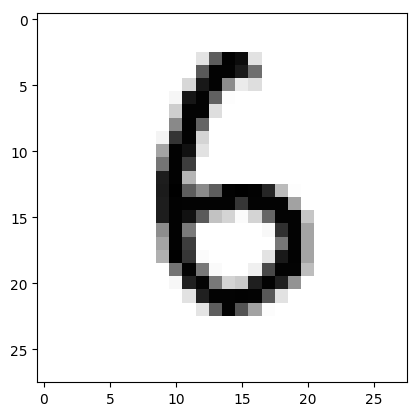

**Sea Slug Data**:

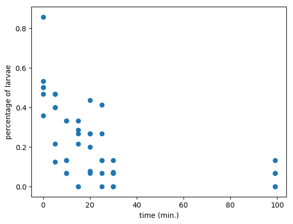

Chapter 2 - Importing data from other file types

Introduction to other files types - Excel spreadsheets, MATLAB, SAS, Stata, HDF5 (becoming a more relevant format for saving data):

- There are also “pickled” files which are native to Python; idea is that you can serialize files like dictionaries or lists for later use in Python (rather than using json which is more human-readable)
- Opening a pickled file: import pickle; with open(“myFile,pkl”, mode=“rb”) as file: data=pickle.load(file)
- Excel files can generally be opened using data=pd.ExcelFile(“myExcel.xlsx”) # assumes previous import pandas as pd; automatically loads the Excel sheet as a data frame
  - data.sheet_names # provides a list of the sheet names
  - df1 = data.parse(“sheetName”) # can pass either the index as a float or the sheet name as a string
  - Can also skip rows and import only certain columns

Importing SAS/Stata files using pandas:

- SAS: Statistical Analysis System is common for business analytics and biostatistics
- Stata: Statistics + Data is common for academic social sciences research
- The most common SAS files have the extensions .sas7bdat and .sas7cdat
  - from sas7bdat import SAS7BDAT
  - with SAS7BDAT(“mySASfile.sas7bdat”) as file: df_sas=file.to_data_frame() # as per previous examples
- The Stata files can be imported directly using pd
  - pd.read_stata(“myStataFile.dta”)

Importing HDF5 (Hierarchical Data Format 5) files, quickly becoming the Python standard for storing large quantities of numerical data:

- HDF5 can scale up to exabytes of data, and is commonly used for files of hundereds of gigabytes or even terabytes
- import h5py; data=h5py.File(“myHD5.hd5”, “r”); for key in data.keys(): print(key)
  - might have “meta”, “quality”, and “strain” for a specific LIGO data file
  - could dive further in to any of the keys, for example for key in data[“meta”].keys(): print(key)
- The HDF project is formally managed by the HDF group, a Champaign-based spinoff of the University of Illinois

Importing MATLAB (MATrix LABoratory) files - industry standard in engineering and science:

- The library scipy has functions scipy.io.loadmat() and scipy.io.savemat()
  - The loaded file will be a dictionary (keys are the variable names and values are the objects assigned to the variables)
- COULD NOT GET scipy to import (lack of blas???)

Example code includes:

```python
myPath = "./PythonInputFiles/"

# Import pickle package
import pickle

# NEED PICKLE DATA - {'Mar': '84.4', 'June': '69.4', 'Airline': '8', 'Aug': '85'}
# Created using with open(myPath + "data.pkl", "wb") as file: pickle.dump(myDict, file)
# Open pickle file and load data: d
with open(myPath + 'data.pkl', mode="rb") as file:
    d = pickle.load(file)

# Print d
print(d)

# Print datatype of d
print(type(d))


# NEED BATTLE DEATHS DATA - https://www.prio.org/Data/Armed-Conflict/Battle-Deaths/The-Battle-Deaths-Dataset-version-30/ (downloaded and converted name to "battledeath.xlsx")
# Import pandas
import pandas as pd

# Assign spreadsheet filename: file
file = myPath + "battledeath.xlsx"

# Load spreadsheet: xl
xl = pd.ExcelFile(file)

# Print sheet names
print(xl.sheet_names)


# Load a sheet into a DataFrame by name: df1
# There is only one sheet absent converting "bdonly" to a file by year
df1 = xl.parse("bdonly")

# Print the head of the DataFrame df1
print(df1.head())

# Load a sheet into a DataFrame by index: df2
df2 = xl.parse(0)

# Print the head of the DataFrame df2
print(df2.head())


# Parse the first sheet and rename the columns: df1
df1 = xl.parse(0, skiprows=[0], parse_cols=[2, 9], names=["AAM due to War (2002)", "Country"])

# Print the head of the DataFrame df1
print(df1.head())

# Parse the tenth column of the first sheet and rename the column: df2
df2 = xl.parse(0, parse_cols=[9], skiprows=[0], names=["Country"])

# Print the head of the DataFrame df2
print(df2.head())


# DO NOT HAVE THIS FILE EITHER
# Import sas7bdat package
from sas7bdat import SAS7BDAT

# Save file to a DataFrame: df_sas
# with SAS7BDAT('sales.sas7bdat') as file:
#     df_sas = file.to_data_frame()

# Print head of DataFrame
# print(df_sas.head())

import matplotlib.pyplot as plt

# Plot histogram of DataFrame features (pandas and pyplot already imported)
# pd.DataFrame.hist(df_sas[['P']])
# plt.ylabel('count')
# plt.show()


# DO NOT HAVE THIS FILE EITHER
# Import pandas

# Load Stata file into a pandas DataFrame: df
# df = pd.read_stata("disarea.dta")

# Print the head of the DataFrame df
# print(df.head())

# Plot histogram of one column of the DataFrame
# pd.DataFrame.hist(df[['disa10']])
# plt.xlabel('Extent of disease')
# plt.ylabel('Number of coutries')
# plt.show()


# DO NOT HAVE THIS FILE EITHER
# Import packages
import numpy as np
import h5py

# Assign filename: file
# file = 'LIGO_data.hdf5'

# Load file: data
# data = h5py.File(file, "r")

# Print the datatype of the loaded file
# print(type(data))

# Print the keys of the file
# for key in data.keys():
#     print(key)


# Get the HDF5 group: group
# group = data["strain"]

# Check out keys of group
# for key in group.keys():
#     print(key)

# Set variable equal to time series data: strain
# strain = data['strain']['Strain'].value

# Set number of time points to sample: num_samples
# num_samples = 10000

# Set time vector
# time = np.arange(0, 1, 1/num_samples)

# Plot data
# plt.plot(time, strain[:num_samples])
# plt.xlabel('GPS Time (s)')
# plt.ylabel('strain')
# plt.show()


# DO NOT HAVE THIS FILE EITHER - see https://www.mcb.ucdavis.edu/faculty-labs/albeck/workshop.htm
# Import package (cannot get to download)
# import scipy.io

# Load MATLAB file: mat
# mat = scipy.io.loadmat('albeck_gene_expression.mat')

# Print the datatype type of mat
# print(type(mat))


# Print the keys of the MATLAB dictionary
# print(mat.keys())

# Print the type of the value corresponding to the key 'CYratioCyt'
# print(type(mat["CYratioCyt"]))

# Print the shape of the value corresponding to the key 'CYratioCyt'
# print(np.shape(mat["CYratioCyt"]))

# Subset the array and plot it
# data = mat['CYratioCyt'][25, 5:]
# fig = plt.figure()
# plt.plot(data)
# plt.xlabel('time (min.)')
# plt.ylabel('normalized fluorescence (measure of expression)')
# plt.show()
```

```
## {'Mar': '84.4', 'June': '69.4', 'Airline': '8', 'Aug': '85'}
## <class 'dict'>
## ['bdonly']
##    id  year  bdeadlow  bdeadhig  bdeadbes  annualdata  source  bdversion  \
## 0   1  1946      1000      9999      1000           2       1          3
## 1   1  1952       450      3000      -999           2       1          3
## 2   1  1967        25       999        82           2       1          3
## 3   2  1946        25       999      -999           0       0          3
## 4   2  1947        25       999      -999           0       0          3
##
##    location    sidea   ...    epend  ependdate ependprec  gwnoa gwnoa2nd  \
## 0   Bolivia  Bolivia   ...        1 1946-07-21     -99.0    145      NaN
## 1   Bolivia  Bolivia   ...        1 1952-04-12     -99.0    145      NaN
## 2   Bolivia  Bolivia   ...        1 1967-10-16     -99.0    145      NaN
## 3  Cambodia   France   ...        0        NaT       NaN    220      NaN
```

[output cut: 44 more lines]

Chapter 3 - Relational databases

Introduction to relational databases - standard discussion of how a relational database (system of tables) works:

- Each of the tables is a data frame, keyed by a primary key (unique identifier for the row in question)
- The tables are all linked by way of the primary keys, and the existence of these keys as columns in some of the other tables
- The relational linking process saves a great deal of space
- Many systems exist, such as PostgreSQL, MySQL, SQLite, and the like
- SQL is an acronym for “Structured Query Language” which is a standard way for interacting with the relational databases

Creating a database engine in Python - goal is to get data out of the relational database using SQL:

- SQLite is nice since it is fast and simple, though other databases may have additional valuable features
- The package “SQLAlchemy” works with many other RDBMS (relational database management systems)
  - from sqlalchemy import create_engine
  - engine = create_engine(“mySQLDatabase.sqlite”) # may have different extensions if a different type of database
  - engine.table_names() # provides the names of all the tables in engine

Querying relational databases in Python - connecting to the engine and then querying (getting data out from) the database:

- SELECT * FROM myTable will bring over all columns of all rows
- General workflow for SQL in Python include: 1) import packages, 2) create the DB engine, 3) connect to the engine, 4) query the database, 5) save query results to a DataFrame, and 6) close the connection
  - Step 3: con = engine.connect()
  - Step 4: rs = con.execute(“valid SQL queries”)
  - Step 5: df = pd.DataFrame(rs.fetchall()) ; df.columns = rs.keys() # if wanting to bring over meaningful column names
  - Step 6: con.close()
- A context manager (with engine.connect() as con) can save the hassle of con.close(), or worse forgetting to close the connection
- Note that rs.fetchmany(size=5) is an option for bringing over just 5 lines from the query (can use numbers other than 5 also)

Querying relational databases directly with pandas - shortcut to the above process:

- df = pd.read_sql_query(“valid SQL code”, engine) # where import pandas as pd and engine = create_engine(“mySQLConnection”) have previously been run

Advanced querying - exploiting table relationships (combining mutliple tables):

- The SQL join to bring 2+ tables together
- SELECT myVars FROM Table1 INNER JOIN Table2 ON joinCriteria
  - Note that the format for variables is Table.Variable, so Orders.CustomerID = Customers.CustomerID

Example code includes:

```python
myPath = "./PythonInputFiles/"

# NEED FILE - may be able to get at http://chinookdatabase.codeplex.com/
# Downloaded the ZIP, extracted the SQLite, and renamed to Chinook.sqlite
# Import necessary module
from sqlalchemy import create_engine

# Create engine: engine
engine = create_engine('sqlite:///' + myPath + 'Chinook.sqlite')  # The sqlite:/// is called the 'connection string'


# Save the table names to a list: table_names
table_names = engine.table_names()

# Print the table names to the shell
print(table_names)


# Import packages
from sqlalchemy import create_engine
import pandas as pd

# Create engine: engine
engine = create_engine('sqlite:///' + myPath + 'Chinook.sqlite')

# Open engine connection: con
con = engine.connect()

# Perform query: rs
rs = con.execute("SELECT * FROM Album")

# Save results of the query to DataFrame: df
df = pd.DataFrame(rs.fetchall())

# Close connection
con.close()

# Print head of DataFrame df
print(df.head())


# Open engine in context manager
# Perform query and save results to DataFrame: df
with engine.connect() as con:
    rs = con.execute("SELECT LastName, Title FROM Employee")
    df = pd.DataFrame(rs.fetchmany(size=3))
    df.columns = rs.keys()

# Print the length of the DataFrame df
print(len(df))

# Print the head of the DataFrame df
print(df.head())


# Create engine: engine
engine = create_engine('sqlite:///' + myPath + 'Chinook.sqlite')

# Open engine in context manager
# Perform query and save results to DataFrame: df
with engine.connect() as con:
    rs = con.execute("SELECT * FROM Employee WHERE EmployeeID >= 6")
    df = pd.DataFrame(rs.fetchall())
    df.columns = rs.keys()

# Print the head of the DataFrame df
print(df.head())


# Create engine: engine
engine = create_engine('sqlite:///' + myPath + 'Chinook.sqlite')

# Open engine in context manager
with engine.connect() as con:
    rs = con.execute("SELECT * FROM Employee ORDER BY BirthDate")
    df = pd.DataFrame(rs.fetchall())

    # Set the DataFrame's column names
    df.columns = rs.keys()

# Print head of DataFrame
print(df.head())


# Import packages
from sqlalchemy import create_engine
import pandas as pd

# Create engine: engine
engine = create_engine('sqlite:///' + myPath + 'Chinook.sqlite')

# Execute query and store records in DataFrame: df
df = pd.read_sql_query("SELECT * FROM Album", engine)

# Print head of DataFrame
print(df.head())

# Open engine in context manager
# Perform query and save results to DataFrame: df1
with engine.connect() as con:
    rs = con.execute("SELECT * FROM Album")
    df1 = pd.DataFrame(rs.fetchall())
    df1.columns = rs.keys()

# Confirm that both methods yield the same result: does df = df1 ?
print(df.equals(df1))


# Import packages
from sqlalchemy import create_engine
import pandas as pd

# Create engine: engine
engine = create_engine('sqlite:///' + myPath + 'Chinook.sqlite')

# Execute query and store records in DataFrame: df
df = pd.read_sql_query("SELECT * FROM Employee WHERE EmployeeId >= 6 ORDER BY BirthDate", engine)

# Print head of DataFrame
print(df.head())


# Open engine in context manager
# Perform query and save results to DataFrame: df
with engine.connect() as con:
    rs = con.execute("SELECT Title, Name FROM Album INNER JOIN Artist ON Album.ArtistID = Artist.ArtistID")
    df = pd.DataFrame(rs.fetchall())
    df.columns = rs.keys()

# Print head of DataFrame df
print(df.head())


# Execute query and store records in DataFrame: df
df = pd.read_sql_query("SELECT * FROM PlaylistTrack INNER JOIN Track ON PlaylistTrack.TrackId = Track.TrackId WHERE Milliseconds < 250000", engine)

# Print head of DataFrame
print(df.head())
```

```
## ['Album', 'Artist', 'Customer', 'Employee', 'Genre', 'Invoice', 'InvoiceLine', 'MediaType', 'Playlist', 'PlaylistTrack', 'Track']
##    0                                      1  2
## 0  1  For Those About To Rock We Salute You  1
## 1  2                      Balls to the Wall  2
## 2  3                      Restless and Wild  2
## 3  4                      Let There Be Rock  1
## 4  5                               Big Ones  3
## 3
##   LastName                Title
## 0    Adams      General Manager
## 1  Edwards        Sales Manager
## 2  Peacock  Sales Support Agent
##    EmployeeId  LastName FirstName       Title  ReportsTo            BirthDate  \
## 0           6  Mitchell   Michael  IT Manager          1  1973-07-01 00:00:00
## 1           7      King    Robert    IT Staff          6  1970-05-29 00:00:00
```

[output cut: 78 more lines]

### *Importing Data in Python (Part II)*

Chapter 1 - Importing Data from the Internet

Importing flat files from the web - non-local files:

- Clicking on URL and downloading files creates reproducibility problems and is non-scalable
- Course covers 1) import and locally save from the web, 2) load datasets in to pandas DataFrames, 3) make HTTP requests, 4) scrape HTML (BeustifulSoup)
- This course will particularly focus on “urllib” and “requests” packages
- The “urllib” package has an interface for fetching data from across the web
  - urllib.urlopen(“myURL”) # Very similar to open() but takes an URL rather than a local file name
  - from urllib.request import urlretrieve ; url = “myQuotedURL” ; urlretrieve(url, “myLocalFileName”)

HTTP requests to import files from the web - unpacking the urlretrieve from urllib.request:

- URL is an acronym for Uniform/Universal Resource Locator (reference to web resources such as web addresses, FTP, and the like)
- Ingredients for an URL include 1) protocol identifier (such as “http:”) and a resource name (such as “datacamp.com”)
- HTTP is an acronym for Hyper-Text Transfer Protocol which is the foundation for data communication on the web
  - Going to a website is the process of sending a GET request through HTTP ; the urlretrieve does this automatically
- HTML is an acronym for HyperText Markup Language, which is the standard mark-up language used on the internet
- Example process for GET requests using urllib
  - from urllib.request import urlopen, Request
  - url = “https://www.wikipedia.org/” ; request = Request(url) ; response = urlopen(request) ; html = response.read() ; response.close()
- Can also send GET requests using “requests”“, a commonly used package that simplifies the process
  - import requests
  - url = “https://www.wikipedia.org/” ; r = requests.get(url) ; text = r.text

Scraping the web in Python using BeautifulSoup - make sense of the jumbled, unstructured HTML data:

- Structured data has either 1) a pre-defined data model, or 2) organization in a defined manner
- HTML is unstructured data, possessing neither of these properties
- BeautifulSoup parses and extracts structured data from HTML
- General usage would include
  - from bs4 import BeautifulSoup ; import requests
  - url = “https://www.crummy.com/software/BeautifulSoup/”
  - r = requests.get(url) ; html_doc = r.text
  - soup = BeautifulSoup(html_doc)
  - print(soup.prettify()) # printes properly indented html code, easier for human parsing

Example code includes:

```python
# Import package
from urllib.request import urlretrieve
import pandas as pd

# Assign url of file: url (ran once - no need to re-run)
# url = 'https://s3.amazonaws.com/assets.datacamp.com/production/course_1606/datasets/winequality-red.csv'

# Save file locally
# urlretrieve(url, 'winequality-red.csv')

# Read file into a DataFrame and print its head
df = pd.read_csv('winequality-red.csv', sep=';')
print(df.head())


# Import packages
import matplotlib.pyplot as plt
import pandas as pd

# Assign url of file: url (ran once - no need to re-run)
# url = 'https://s3.amazonaws.com/assets.datacamp.com/production/course_1606/datasets/winequality-red.csv'

# Read file into a DataFrame: df
# df = pd.read_csv(url, sep=";")

# Print the head of the DataFrame
# print(df.head())

# Plot first column of df
pd.DataFrame.hist(df.ix[:, 0:1])
plt.xlabel('fixed acidity (g(tartaric acid)/dm$^3$)')
plt.ylabel('count')
# plt.show()
plt.savefig("_dummyPy044.png", bbox_inches="tight")
plt.clf()


# Assign url of file: url
url = 'http://s3.amazonaws.com/assets.datacamp.com/course/importing_data_into_r/latitude.xls'

# Read in all sheets of Excel file: xl
xl = pd.read_excel(url, sheetname=None)

# Print the sheetnames to the shell
print(xl.keys())

# Print the head of the first sheet (using its name, NOT its index)
print(xl["1700"].head())


# Import packages
from urllib.request import urlopen, Request

# Specify the url
url = "http://www.datacamp.com/teach/documentation"

# This packages the request: request
request = Request(url)

# Sends the request and catches the response: response
response = urlopen(request)

# Print the datatype of response
print(type(response))

# Be polite and close the response!
response.close()


# Specify the url
url = "http://docs.datacamp.com/teach/"

# This packages the request
request = Request(url)

# Sends the request and catches the response: response
response = urlopen(request)

# Extract the response: html
html = response.read()

# Print the html
print(html)

# Be polite and close the response!
response.close()


import requests

# Specify the url: url
url = "http://docs.datacamp.com/teach/"

# Packages the request, send the request and catch the response: r
r = requests.get(url)

# Extract the response: text
text = r.text

# Print the html
print(text)


# Import packages
import requests
from bs4 import BeautifulSoup

# Specify url: url
url = 'https://www.python.org/~guido/'

# Package the request, send the request and catch the response: r
r = requests.get(url)

# Extracts the response as html: html_doc
html_doc = r.text

# Create a BeautifulSoup object from the HTML: soup
soup = BeautifulSoup(html_doc)

# Prettify the BeautifulSoup object: pretty_soup
pretty_soup = soup.prettify()

# Print the response
print(pretty_soup)


# Get the title of Guido's webpage: guido_title
guido_title = soup.title

# Print the title of Guido's webpage to the shell
print(guido_title)

# Get Guido's text: guido_text
guido_text = soup.get_text()

# Print Guido's text to the shell
print(guido_text)


# Find all 'a' tags (which define hyperlinks): a_tags
a_tags = soup.find_all("a")

# Print the URLs to the shell
for link in a_tags:
    print(link.get("href"))
```

```
##    fixed acidity  volatile acidity  citric acid  residual sugar  chlorides  \
## 0            7.4              0.70         0.00             1.9      0.076
## 1            7.8              0.88         0.00             2.6      0.098
## 2            7.8              0.76         0.04             2.3      0.092
## 3           11.2              0.28         0.56             1.9      0.075
## 4            7.4              0.70         0.00             1.9      0.076
##
##    free sulfur dioxide  total sulfur dioxide  density    pH  sulphates  \
## 0                 11.0                  34.0   0.9978  3.51       0.56
## 1                 25.0                  67.0   0.9968  3.20       0.68
## 2                 15.0                  54.0   0.9970  3.26       0.65
## 3                 17.0                  60.0   0.9980  3.16       0.58
## 4                 11.0                  34.0   0.9978  3.51       0.56
##
##    alcohol  quality
## 0      9.4        5
## 1      9.8        5
## 2      9.8        5
## 3      9.8        6
## 4      9.4        5
## odict_keys(['1700', '1900'])
##                  country       1700
## 0            Afghanistan  34.565000
## 1  Akrotiri and Dhekelia  34.616667
## 2                Albania  41.312000
## 3                Algeria  36.720000
## 4         American Samoa -14.307000
## <class 'http.client.HTTPResponse'>
## b'<!DOCTYPE html>\n<link rel="shortcut icon" href="images/favicon.ico" />\n<html>\n\n  <head>\n  <meta charset="utf-8">\n  <meta http-equiv="X-UA-Compatible" content="IE=edge">\n  <meta name="viewport" content="width=device-width, initial-scale=1">\n\n  <title>Home</title>\n  <meta name="descript…
## <!DOCTYPE html>
## <link rel="shortcut icon" href="images/favicon.ico" />
## <html>
##
##   <head>
##   <meta charset="utf-8">
##   <meta http-equiv="X-UA-Compatible" content="IE=edge">
##   <meta name="viewport" content="width=device-width, initial-scale=1">
##
##   <title>Home</title>
##   <meta name="description" content="All Documentation on Course Creation">
```

[output cut: 376 more lines]

```
## pics.html
## http://neopythonic.blogspot.com
## http://www.artima.com/weblogs/index.jsp?blogger=12088
## https://twitter.com/gvanrossum
## https://plus.google.com/u/0/115212051037621986145/posts
## http://www.dropbox.com
## Resume.html
## http://groups.google.com/groups?q=comp.lang.python
## http://stackoverflow.com
## guido.au
## http://legacy.python.org/doc/essays/
## images/license.jpg
## http://www.cnpbagwell.com/audio-faq
## http://sox.sourceforge.net/
## images/internetdog.gif
```

**Acidity of Red Wine**:

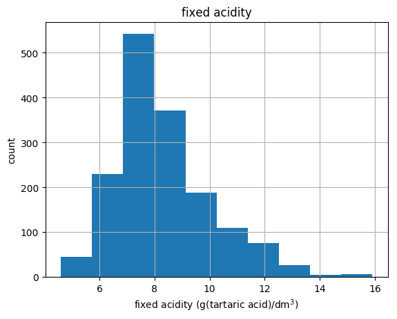

Chapter 2 - Interacting with APIs

Introduction to APIs (Application Programming Interface) and JSON (JavaScript Object Notation):

- API is a protocol and routine for building and interacting with software applications
- JSON helps with rel-time browser to server communication, developed by Douglas Crockford
- JSON has name-value pairs, very similar to a Python dictionary
- General process might include
  - import json
  - with open(“snakes.json”, “r”) as json_file: json_data = json.load(json_file) # json_data will be imported as a dictionary

APIs and interacting with the world-wide web - what APIs are and why they are important:

- The API is a set of protocols and routines for interacting with software programs
- The “Open Movies Database” (OMDB) has an API, as do most websites that might be data sources
- Example usage might include
  - import requests
  - url = “http://www.omdbapi.com/?t=hackers” # the ? Represents a “query string”, in this case asking for “t” (title) equals “hackers” (the movie “Hackers”)
  - r = requests.get(url)
  - json_data = r.json()
- Can get the OMDB API webpage for how they allow their data to be queried/used and how to fomat the relevant “query strings”

Example code includes:

```python
myPath = "./PythonInputFiles/"

# DO NOT HAVE FILE a_movie.json, which appears to be JSON for the movie Social Network (2010)
# Created and saved file
import json

# Load JSON: json_data
with open(myPath + "a_movie.json") as json_file:
    json_data = json.load(json_file)

# Print each key-value pair in json_data
for k in json_data.keys():
    print(k + ': ', json_data[k])


# PROBABLY DO NOT RUN; NEED API KEY
# Import requests package
import requests

# Assign URL to variable: url
url = 'http://www.omdbapi.com/?apikey=ff21610b&t=social+network'

# Package the request, send the request and catch the response: r
r = requests.get(url)

# Print the text of the response
print(r.text)

# Decode the JSON data into a dictionary: json_data
json_data = r.json()

# Print each key-value pair in json_data
for k in json_data.keys():
    print(k + ': ', json_data[k])


# Assign URL to variable: url
url = "https://en.wikipedia.org/w/api.php?action=query&prop=extracts&format=json&exintro=&titles=pizza"

# Package the request, send the request and catch the response: r
r = requests.get(url)

# Decode the JSON data into a dictionary: json_data
json_data = r.json()

# Print the Wikipedia page extract
pizza_extract = json_data['query']['pages']['24768']['extract']
print(pizza_extract)
```

```
## imdbRating:  7.7
## Rated:  PG-13
## Year:  2010
## DVD:  N/A
## Ratings:  [{'Value': '7.7/10', 'Source': 'Internet Movie Database'}, {'Value': '96%', 'Source': 'Rotten Tomatoes'}, {'Value': '95/100', 'Source': 'Metacritic'}]
## Metascore:  95
## Runtime:  120 min
## Released:  01 Oct 2010
## Plot:  Harvard student Mark Zuckerberg creates the social networking site that would become known as Facebook, but is later sued by two brothers who claimed he stole their idea, and the co-founder who was later squeezed out of the business.
## Poster:  https://images-na.ssl-images-amazon.com/images/M/MV5BMTM2ODk0NDAwMF5BMl5BanBnXkFtZTcwNTM1MDc2Mw@@._V1_SX300.jpg
## imdbVotes:  508,540
## Director:  David Fincher
## Website:  http://www.thesocialnetwork-movie.com/
## Writer:  Aaron Sorkin (screenplay), Ben Mezrich (book)
## Awards:  Won 3 Oscars. Another 162 wins & 162 nominations.
## Language:  English, French
## Genre:  Biography, Drama
## Type:  movie
## Country:  USA
## Production:  Columbia Pictures
## imdbID:  tt1285016
## Actors:  Jesse Eisenberg, Rooney Mara, Bryan Barter, Dustin Fitzsimons
## BoxOffice:  $96,400,000
## Response:  True
## Title:  The Social Network
## {"Title":"The Social Network","Year":"2010","Rated":"PG-13","Released":"01 Oct 2010","Runtime":"120 min","Genre":"Biography, Drama","Director":"David Fincher","Writer":"Aaron Sorkin (screenplay), Ben Mezrich (book)","Actors":"Jesse Eisenberg, Rooney Mara, Bryan Barter, Dustin Fitzsimons","Plot":"…
## Title:  The Social Network
## Year:  2010
## Rated:  PG-13
## Released:  01 Oct 2010
## Runtime:  120 min
## Genre:  Biography, Drama
## Director:  David Fincher
## Writer:  Aaron Sorkin (screenplay), Ben Mezrich (book)
## Actors:  Jesse Eisenberg, Rooney Mara, Bryan Barter, Dustin Fitzsimons
## Plot:  Harvard student Mark Zuckerberg creates the social networking site that would become known as Facebook, but is later sued by two brothers who claimed he stole their idea, and the co-founder who was later squeezed out of the business.
## Language:  English, French
## Country:  USA
## Awards:  Won 3 Oscars. Another 165 wins & 169 nominations.
## Poster:  https://images-na.ssl-images-amazon.com/images/M/MV5BMTM2ODk0NDAwMF5BMl5BanBnXkFtZTcwNTM1MDc2Mw@@._V1_SX300.jpg
## Ratings:  [{'Source': 'Internet Movie Database', 'Value': '7.7/10'}, {'Source': 'Rotten Tomatoes', 'Value': '96%'}, {'Source': 'Metacritic', 'Value': '95/100'}]
## Metascore:  95
## imdbRating:  7.7
## imdbVotes:  514,092
## imdbID:  tt1285016
## Type:  movie
## DVD:  11 Jan 2011
## BoxOffice:  $96,400,000
## Production:  Columbia Pictures
## Website:  http://www.thesocialnetwork-movie.com/
## Response:  True
## <p><b>Pizza</b> is a yeasted flatbread typically topped with tomato sauce and cheese and baked in an oven. It is commonly topped with a selection of meats, vegetables and condiments.</p>
## <p>The term <i>pizza</i> was first recorded in the 10th century, in a Latin manuscript from Gaeta in Central Italy. Modern pizza was invented in Naples, Italy, and the dish and its variants have since become popular and common in many areas of the world. In 2009, upon Italy's request, Neapolitan …
## <p>Pizza is sold fresh or frozen, either whole or in portions, and is a common fast food item in Europe and North America. Various types of ovens are used to cook them and many varieties exist. Several similar dishes are prepared from ingredients commonly used in pizza preparation, such as calzon…
```

Chapter 3 - Diving deeper in to the Twitter API

Twitter API and Authentication - 1) Twitter API, 2) filtering tweets, 3) API Authentication and Oauth, 4) Python package “tweepy”:

- The Twitter API requires a Twitter account, then creating a new Twitter App, then copying over the Token and Token Secret
- Twitter has many API including the REST API (Representational State API), which allows for reading and writing Twitter data
- The Twitter Streaming API includes a “Public streams” for low-latency access to tweets
- The Twitter Firehose API is not publicly avaiable, requires special permission, and would likely be very expensive
- Tweets are generally returned as JSON
- The “tweepy” package has a nice balance between functionality and usability
  - auth = tweepy.OAuthHandler(consumer_key, consumer_secret)
  - auth.set_access(access_token, access_token_secret)

Example code includes:

```python
# DO NOT RUN THIS - NO IDEA WHOSE KEYS THESE ARE (DataCamp???)
# Import package
import tweepy

# Store OAuth authentication credentials in relevant variables
access_token = "1092294848-aHN7DcRP9B4VMTQIhwqOYiB14YkW92fFO8k8EPy"
access_token_secret = "X4dHmhPfaksHcQ7SCbmZa2oYBBVSD2g8uIHXsp5CTaksx"
consumer_key = "nZ6EA0FxZ293SxGNg8g8aP0HM"
consumer_secret = "fJGEodwe3KiKUnsYJC3VRndj7jevVvXbK2D5EiJ2nehafRgA6i"

# Pass OAuth details to tweepy's OAuth handler
auth = tweepy.OAuthHandler(consumer_key, consumer_secret)
auth.set_access_token(access_token, access_token_secret)


# The class MyStreamListener is available at https://gist.github.com/hugobowne/18f1c0c0709ed1a52dc5bcd462ac69f4
# Initialize Stream listener
l = MyStreamListener()

# Create you Stream object with authentication
stream = tweepy.Stream(auth, l)

# Filter Twitter Streams to capture data by the keywords:
stream.filter(track=['clinton', 'trump', 'sanders', 'cruz'])


# Import package
import json

# String of path to file: tweets_data_path
tweets_data_path = "tweets.txt"

# Initialize empty list to store tweets: tweets_data
tweets_data = []

# Open connection to file
tweets_file = open(tweets_data_path, "r")

# Read in tweets and store in list: tweets_data
for line in tweets_file:
    tweet = json.loads(line)
    tweets_data.append(tweet)

# Close connection to file
tweets_file.close()

# Print the keys of the first tweet dict
print(tweets_data[0].keys())


# Import package
import pandas as pd

# Build DataFrame of tweet texts and languages
df = pd.DataFrame(tweets_data, columns=["text", "lang"])

# Print head of DataFrame
print(df.head())


def word_in_text(word, tweet):
    word = word.lower()
    text = tweet.lower()
    match = re.search(word, tweet)

    if match:
        return True
    return False


# Initialize list to store tweet counts
[clinton, trump, sanders, cruz] = [0, 0, 0, 0]

# Iterate through df, counting the number of tweets in which
# each candidate is mentioned
for index, row in df.iterrows():
    clinton += word_in_text('clinton', row['text'])
    trump += word_in_text('trump', row['text'])
    sanders += word_in_text('sanders', row['text'])
    cruz += word_in_text('cruz', row['text'])


# Import packages
import matplotlib.pyplot as plt
import seaborn as sns

# Set seaborn style
sns.set(color_codes=True)

# Create a list of labels:cd
cd = ['clinton', 'trump', 'sanders', 'cruz']

# Plot histogram
ax = sns.barplot(cd, [clinton, trump, sanders, cruz])
ax.set(ylabel="count")
plt.show()
```

### *Cleaning Data in Python*

Chapter 1 - Exploring Your Data

Diagnose data for cleaning - column names, missing data, outliers, duplicate rows, un-tidy data, unexpected data values, etc.:

- Pandas can be identified/filtered using row/column names or row/column indices
- Missing data are typically NaN in Python
- For a pandas DataFrame df, df.head() and df.tail() will show the first/last 5 rows
  - df.columns returns an index of column names, which can reveal leading/trailing spaces
  - df.shape is analogous to dim() in R
  - df.info() will give a summary of the frame, as well as the associated columns (data types, non-missing values, and the like) - note that type “object” means it is non-numeric

Exploratory data analysis - suppose that a pandas DataFrame, df, has already been created:

- To get frequency counts, use df.continent.value_counts(dropna=False) # in this case “continent” is the column name (can also subset using bracket notation, which is required if name has any “problems”). . .
  - Frequency counts will be in descending order
  - df[“continent”].value_counts(dropna=False) will return the same thing
- To get summaries of numeric data, use df.describe() # will only be run for numeric columns

Visual exploratory data analysis - easy way to spot outliers and obvious errors - assume again that a pandas DataFrame, df, has already been explained:

- Bar plots for discrete data
- Histograms for contiuous data - df[“myColumn”].plot(“hist”) will create the histogram, and plt.show() will then show the histogram
- Data can be subset similar to R - df[df[“myVar”] condition] will pull only the rows where the specified condition is met
- Box plots can be handy ways to summarize the numerical data - df.boxplot(column=“myColumn”, by=“myByVariable”)
- Scatter plots can be handy ways to look at relationships between two numeric columns

Example code includes:

```python
# Downloaded small portion to myPath from https://data.cityofnewyork.us/Housing-Development/DOB-Job-Application-Filings/ic3t-wcy2/data

# tempData = pd.read_csv(myPath + "DOB_JOB_Application_Filings.csv")

# keyCols = ["Borough", "State", "Site Fill", "Existing Zoning Sqft", "Initial Cost", "Total Est. Fee"]
# useData = tempData[keyCols]
# useData.loc[:, "initial_cost"] = [float(d[1:]) for d in useData["Initial Cost"]]
# useData.loc[:, "total_est_fee"] = [float(d[1:]) for d in useData["Total Est. Fee"]]
# useData.to_csv(myPath + "dob_job_application_filings_subset.csv")

# MAY NEED TO GET DATA FROM https://opendata.cityofnewyork.us/
# Import pandas
import pandas as pd

myPath = "./PythonInputFiles/"


# Read the file into a DataFrame: df
df = pd.read_csv(myPath + 'dob_job_application_filings_subset.csv')

# Print the head of df
print(df.head())

# Print the tail of df
print(df.tail())

# Print the shape of df
print(df.shape)

# Print the columns of df
print(df.columns)

# Print the info of df
print(df.info())


# Print the value counts for 'Borough'
print(df['Borough'].value_counts(dropna=False))

# Print the value_counts for 'State'
print(df['State'].value_counts(dropna=False))

# Print the value counts for 'Site Fill'
print(df['Site Fill'].value_counts(dropna=False))


# Import matplotlib.pyplot
import matplotlib.pyplot as plt

# Plot the histogram
df['Existing Zoning Sqft'].plot(kind='hist', rot=70, logx=True, logy=True)

# Display the histogram
# plt.show()
plt.savefig("_dummyPy045.png", bbox_inches="tight")
plt.clf()

# Import necessary modules
import pandas as pd
import matplotlib.pyplot as plt

# Create the boxplot
df.boxplot(column="initial_cost", by="Borough", rot=90)

# Display the plot
# plt.show()
plt.savefig("_dummyPy046.png", bbox_inches="tight")
plt.clf()

# Import necessary modules
import pandas as pd
import matplotlib.pyplot as plt

# Create and display the first scatter plot
df.plot(kind="scatter", x="initial_cost", y="total_est_fee", rot=70)
# plt.show()
plt.savefig("_dummyPy047.png", bbox_inches="tight")
plt.clf()
```

```
##    Unnamed: 0    Borough State            Site Fill  Existing Zoning Sqft  \
## 0           0   BROOKLYN    NY  USE UNDER 300 CU.YD                     0
## 1           1   BROOKLYN    NY                  NaN                     0
## 2           2  MANHATTAN    NY       NOT APPLICABLE                     0
## 3           3     QUEENS    NY       NOT APPLICABLE                     0
## 4           4   BROOKLYN    NY       NOT APPLICABLE                     0
##
##   Initial Cost Total Est. Fee  initial_cost  total_est_fee
## 0        $0.00        $420.00           0.0          420.0
## 1        $0.00        $170.00           0.0          170.0
## 2    $60000.00        $831.50       60000.0          831.5
## 3    $31000.00        $692.80       31000.0          692.8
## 4     $3000.00        $225.00        3000.0          225.0
##      Unnamed: 0   Borough State            Site Fill  Existing Zoning Sqft  \
## 138         138    QUEENS    NY                  NaN                     0
## 139         139    QUEENS    NY       NOT APPLICABLE                     0
## 140         140  BROOKLYN    NY       NOT APPLICABLE                     0
## 141         141  BROOKLYN    NY  USE UNDER 300 CU.YD                     0
## 142         142     BRONX    NY                  NaN                     0
##
##     Initial Cost Total Est. Fee  initial_cost  total_est_fee
## 138    $63000.00        $832.40       63000.0          832.4
## 139    $21000.00        $212.40       21000.0          212.4
## 140     $2800.00        $395.00        2800.0          395.0
## 141        $0.00        $472.00           0.0          472.0
## 142        $0.00        $170.00           0.0          170.0
## (143, 9)
## Index(['Unnamed: 0', 'Borough', 'State', 'Site Fill', 'Existing Zoning Sqft',
##        'Initial Cost', 'Total Est. Fee', 'initial_cost', 'total_est_fee'],
##       dtype='object')
## <class 'pandas.core.frame.DataFrame'>
## RangeIndex: 143 entries, 0 to 142
## Data columns (total 9 columns):
## Unnamed: 0              143 non-null int64
## Borough                 143 non-null object
## State                   143 non-null object
## Site Fill               120 non-null object
## Existing Zoning Sqft    143 non-null int64
## Initial Cost            143 non-null object
## Total Est. Fee          143 non-null object
## initial_cost            143 non-null float64
## total_est_fee           143 non-null float64
## dtypes: float64(2), int64(2), object(5)
## memory usage: 7.3+ KB
## None
## MANHATTAN        66
## BROOKLYN         44
## QUEENS           16
## STATEN ISLAND    10
## BRONX             7
## Name: Borough, dtype: int64
## NY    136
## NJ      6
## NC      1
## Name: State, dtype: int64
## NOT APPLICABLE         108
## NaN                     23
## USE UNDER 300 CU.YD      8
## ON-SITE                  4
## Name: Site Fill, dtype: int64
```

**NYC Open Data Sub-sample (Building Permits - Existing Zoning Sq Ft)**:

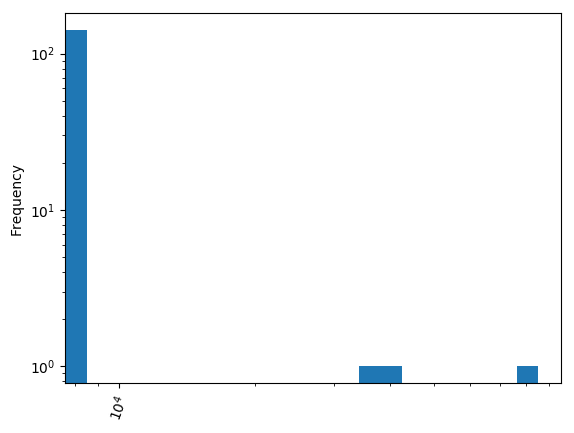

**NYC Open Data Sub-sample (Building Permits - Initial Cost by Borough)**:

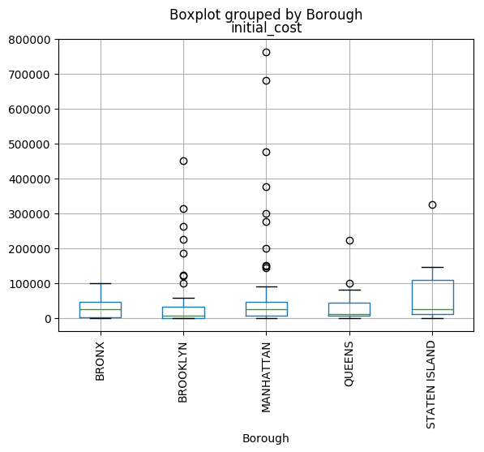

**NYC Open Data Sub-sample (Building Permits)**:

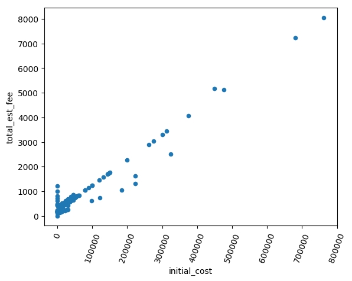

Chapter 2 - Tidying data for analysis

Tidy data per the Hadley Wickham paper - “standard way to organize data within a dataset”:

- Columns should represent separate variables - if the values are in the column names, then the data need to be melted
  - pd.melt(frame=myFrame, id_vars=[“myID”], value_vars=[“myValues”])
  - id_vars will be held fixed; these are the columns that will not be changed during the melting process
  - If the value_vars columns are not specified, Python will assume you want to melt all columns other than the ID variables
  - The default outputs new columns “variable” and “value”, though these can be over-ridden using var_name=“myVarName” and value_name=“myValName” inside melt
- Rows should represent individual observations
- Observational units should form tables
- There are some trade-offs in reporting vs. data analysis, and tidying the data is primarily for making it easier to analyze

Pivoting data is the opposite of melting; turn unique values in to separate columns (assuming again that the DataFrame, df, already exists):

- To pivot the data, use df.pivot(index=“myIndex”, columns=“myColumns”, values=“myValues”)
  - index is the columns to be fixed
  - columns is what is to be pivoted in the new columns
  - values is what is to be placed in to the new columns
- If there is a duplicate value, the “pivot table” is required, specifying to Python how the duplicated value should be managed
  - df.pivot_table(index=“myIndex”, columns=“myColumns”, values=“myValues”, aggfunc=myFunc) # same as .pivot, but specifying something like np.mean for how to handle duplicates

Beyond melt and pivot - example from the Wickham data of having a single variable that combines sex and age-group (TB data) - common shape for reporting, but less than ideal for analysis:

- First, melt the data so that all these columns become a single “variable” that contains the associated “value”
- Second, create new variables for sex and age from the current variable named “variable”
  - tb_melt[“sex”] = tb_melt[“variable”].str[0] # will extract the first character, which is the sex in this case
  - tb_melt[“age”] = tb_melt[“variable”].str[1:] # will extract all but the first character

Example code includes:

```python
# THIS SEEMS TO BE THE STANARD R datasets file as a pandas
# Saved airquality.csv to the ./PythonInputFiles

myPath = "./PythonInputFiles/"



import pandas as pd
import numpy as np

airquality = pd.read_csv(myPath + "airquality.csv")


# Print the head of airquality
print(airquality.head())

# Melt airquality: airquality_melt
airquality_melt = pd.melt(airquality, id_vars=["Month", "Day"])

# Print the head of airquality_melt
print(airquality_melt.head())


# Print the head of airquality
print(airquality.head())

# Melt airquality: airquality_melt
airquality_melt = pd.melt(airquality, id_vars=["Month", "Day"], var_name="measurement", value_name="reading")

# Print the head of airquality_melt
print(airquality_melt.head())


# Print the head of airquality_melt
print(airquality_melt.head())

# airquality_melt.pivot() would bomb out on this; not sure why . . . (may be due to having 2+ variables in the index
# Pivot airquality_melt: airquality_pivot
airquality_pivot = airquality_melt.pivot_table(index=["Month", "Day"], columns="measurement", values="reading")

# Print the head of airquality_pivot
print(airquality_pivot.head())


# Print the index of airquality_pivot
print(airquality_pivot.index)

# Reset the index of airquality_pivot: airquality_pivot
airquality_pivot = airquality_pivot.reset_index()

# Print the new index of airquality_pivot
print(airquality_pivot.index)

# Print the head of airquality_pivot
print(airquality_pivot.head())


# Pivot airquality_dup: airquality_pivot
# keyRows = [x for x in range(len(airquality.index))] + [2, 4, 6, 8, 10]
# airquality_dup = airquality.iloc[keyRows, :]
airquality_pivot = airquality_melt.pivot_table(index=["Month", "Day"], columns="measurement", values="reading", aggfunc=np.mean)

# Reset the index of airquality_pivot
airquality_pivot = airquality_pivot.reset_index()

# Print the head of airquality_pivot
print(airquality_pivot.head())

# Print the head of airquality
print(airquality.head())


# tb is 201x18 with variables ['country', 'year', 'm014', 'm1524', 'm2534', 'm3544', 'm4554', 'm5564', 'm65', 'mu', 'f014', 'f1524', 'f2534', 'f3544', 'f4554', 'f5564', 'f65', 'fu']
# year is set to be always 2000 with fu and mu always NaN
# Create dummy data for tb (just use 3 countries and the 014 and 1524 columns)
tb = pd.DataFrame( { "country":["USA", "CAN", "MEX"] , "year":2000 , "fu":np.nan , "mu":np.nan , "f014":[2, 3, 4] , "m014":[5, 6, 7] , "f1524": [8, 9, 0] , "m1524":[1, 2, 3] } )


# Melt tb: tb_melt
tb_melt = pd.melt(tb, id_vars=["country", "year"])

# Create the 'gender' column
tb_melt['gender'] = tb_melt.variable.str[0]

# Create the 'age_group' column
tb_melt['age_group'] = tb_melt.variable.str[1:]

# Print the head of tb_melt
print(tb_melt.head())  # Is now 3,216 x 6 ['country', 'year', 'variable', 'value', 'gender', 'age_group']


# Ebola dataset is available at https://data.humdata.org/dataset/ebola-cases-2014
# Variables are split by an underscore 'Date', 'Day', 'Cases_Guinea', 'Cases_Liberia', 'Cases_SierraLeone', 'Cases_Nigeria', 'Cases_Senegal', 'Cases_UnitedStates', 'Cases_Spain', 'Cases_Mali', 'Deaths_Guinea', 'Deaths_Liberia', 'Deaths_SierraLeone', 'Deaths_Nigeria', 'Deaths_Senegal', 'Deaths_UnitedStates', 'Deaths_Spain', 'Deaths_Mali'

# Downloaded file, then manipulated to be like the above as follows:
# ebola_test = pd.read_csv(myPath + "ebola_data_db_format.csv")
# ebola_test["UseCountry"] = ebola_test["Country"].str.replace(" ", "")
# ebola_test["UseCountry"] = ebola_test["UseCountry"].str.replace("2", "")
# keyIndic = ["Cumulative number of confirmed Ebola deaths", "Cumulative number of confirmed Ebola cases"]
# keyBool = [x in keyIndic for x in ebola_test["Indicator"]]
# ebola_test = ebola_test.loc[keyBool, :]
# indicMap = {keyIndic[0]:"Deaths", keyIndic[1]:"Cases"}
# ebola_test["UseIndicator"] = ebola_test["Indicator"].map(indicMap)
# ebolaPre = ebola_test[["Date", "UseCountry", "UseIndicator", "value"]]
# ebolaPre["CI"] = ebolaPre["UseIndicator"] + "_" + ebolaPre["UseCountry"]
# ebolaSave = ebolaPre.pivot_table(index="Date", columns="CI", values="value", aggfunc="max").fillna(method="ffill").fillna(0)
# ebolaSave.to_csv(myPath + "ebola.csv")

ebola = pd.read_csv(myPath + "ebola.csv", parse_dates=["Date"])


# Melt ebola: ebola_melt
ebola_melt = pd.melt(ebola, id_vars=["Date"], var_name="type_country", value_name="counts")

# Create the 'str_split' column
ebola_melt['str_split'] = ebola_melt["type_country"].str.split("_")

# Create the 'type' column
ebola_melt['type'] = ebola_melt['str_split'].str.get(0)

# Create the 'country' column
ebola_melt['country'] = ebola_melt['str_split'].str.get(1)

# Print the head of ebola_melt
print(ebola_melt.head())


# ebola_melt.to_csv(myPath + "ebola_melt.csv", index=False)
# Run outside of this shell so that the file is accessible later
```

```
##    Ozone  Solar.R  Wind  Temp  Month  Day
## 0   41.0    190.0   7.4    67      5    1
## 1   36.0    118.0   8.0    72      5    2
## 2   12.0    149.0  12.6    74      5    3
## 3   18.0    313.0  11.5    62      5    4
## 4    NaN      NaN  14.3    56      5    5
##    Month  Day variable  value
## 0      5    1    Ozone   41.0
## 1      5    2    Ozone   36.0
## 2      5    3    Ozone   12.0
## 3      5    4    Ozone   18.0
## 4      5    5    Ozone    NaN
##    Ozone  Solar.R  Wind  Temp  Month  Day
## 0   41.0    190.0   7.4    67      5    1
## 1   36.0    118.0   8.0    72      5    2
```

[output cut: 56 more lines]

Chapter 3 - Combining data for analysis

Concatenating data - data may be in separate files (too many records, time series data by day, etc.), while you want to combine it:

- Concatenating data (similar to rbind in R) in Python leaves the original row indices untouched, which can induce duplicate indices
- The pd.concat([myFileList]) will place the frames together in a single frame # requires that import pandas as pd was called previously
  - Using ignore_index=True inside pd.concat() will re-cast the row indices from 0 to n-1
  - To instead concatenate columns (similar to cbind in R), declare the axis=1 option inside pd.concat()

Finding and concatenating data - issue of many files needing to be concatenated:

- The glob function from the glob library helps to find files based on a consistent search pattern
  - The wildcards * and ? Are both available, with * being any number while ? Is a single character
  - Basic usage would be glob.glob(“mySearchString”)
- The basic plan would be to 1) load all the files to pandas, and then 2) make a list of the DataFrame names for concatenation

Merge data - extension on concatenation (which is more piecing something back together that was originally one piece but became split):

- Merging can manage joins of tables that never were one piece, combining disparate data based on common columns
- The merge syntax is pd.merge(left=leftFrame, right=rightFrame, how=, on=, left_on=, right_on=) # default is an INNER JOIN and need to specify either on= (common variables) or left_on=/right_on=
  - The defaults for on, left_on, and right_on are all None
  - The default is for how=“inner” though options for “left”, “right”, and “outer” can also be declared

Example code includes:

```python
myPath = "./PythonInputFiles/"

import pandas as pd
import numpy as np


# uber datasets are a small subset from within http://data.beta.nyc/dataset/uber-trip-data-foiled-apr-sep-2014
# downloaded file "Uber-Jan-Feb-FOIL.csv" to myPath


uber = pd.read_csv(myPath + "Uber-Jan-Feb-FOIL.csv")

cuts = [round(len(uber.index) / 3), round(2 * len(uber.index) / 3)]

uber1 = uber.iloc[:cuts[0], :]
uber2 = uber.iloc[cuts[0]:cuts[1], :]
uber3 = uber.iloc[cuts[1]:, :]

# Save outside of this routine
# uber1.to_csv(myPath + "uber1.csv", index=False)
# uber2.to_csv(myPath + "uber2.csv", index=False)
# uber3.to_csv(myPath + "uber3.csv", index=False)


# Concatenate uber1, uber2, and uber3: row_concat
row_concat = pd.concat([uber1, uber2, uber3])

# Print the shape of row_concat
print(row_concat.shape)

# Print the head of row_concat
print(row_concat.head())

print(np.sum(row_concat != uber))


# ebola_melt is 1,952x4 of Date-Day-status_country-counts
# status_country is 1,952x2 of status-country (the previous status_country has been string split)
# Create this from the file in the previous exercise
ebola_melt = pd.read_csv(myPath + "ebola_melt.csv", parse_dates=["Date"])
ebola_melt.columns = ["Date", "status_country", "counts", "str_split", "status", "country"]

status_country = ebola_melt[["status", "country"]]
ebola_melt = ebola_melt[["Date", "status_country", "counts"]]

# Concatenate ebola_melt and status_country column-wise: ebola_tidy
ebola_tidy = pd.concat([ebola_melt, status_country], axis=1)

# Print the shape of ebola_tidy
print(ebola_tidy.shape)

# Print the head of ebola_tidy
print(ebola_tidy.head())


# Has files ['uber-raw-data-2014_06.csv', 'uber-raw-data-2014_04.csv', 'uber-raw-data-2014_05.csv'] available
# Date/Time-Lat-Lon-Base
# Import necessary modules
import glob
import pandas as pd

# Write the pattern: pattern
# This is designed to get the uber1.csv, uber2.csv, and uber3.csv files
pattern = myPath + 'uber?.csv'

# Save all file matches: csv_files
csv_files = glob.glob(pattern)

# Print the file names
print(csv_files)

# Load the second file into a DataFrame: csv2
csv2 = pd.read_csv(csv_files[1])

# Print the head of csv2
print(csv2.head())


# Create an empty list: frames
frames = []

#  Iterate over csv_files
for csv in csv_files:

    #  Read csv into a DataFrame: df
    df = pd.read_csv(csv)

    # Append df to frames
    frames.append(df)

# Concatenate frames into a single DataFrame: uber
uber = pd.concat(frames)

# Print the shape of uber
print(uber.shape)

# Print the head of uber
print(uber.head())


# site is a 3x3 with name-lat-long - name=["DR-1", "DR-3", "MSK-4"], lat=[-50, -47, -48.9], lon=[-129, -127, -123.4]
# visited is a 3x3 with ident-site-dated - ident=[619, 734, 837], site=["DR-1", "DR-3", "MSK-4"], dated=["1927-02", "1939-01", "1932-01"]

site = pd.DataFrame( { "name":["DR-1", "DR-3", "MSK-4"], "lat":[-50, -47, -48.9], "lon":[-129, -127, -123.4] } )
visited = pd.DataFrame( { "ident":[619, 734, 837], "site":["DR-1", "DR-3", "MSK-4"], "dated":["1927-02", "1939-01", "1932-01"] } )

# Merge the DataFrames: o2o
o2o = pd.merge(left=site, right=visited, left_on=["name"], right_on=["site"])

# Print o2o
print(o2o)


# now make visited 8x3 with ident=[619, 622, 734, 735, , 751, 752, 837, 844], site=['DR-1', 'DR-1', 'DR-3', 'DR-3', 'DR-3', 'DR-3', 'MSK-4', 'DR-1'], dated=['1927-02-08', '1927-02-10', '1939-01-07', '1930-01-12', '1930-02-26', nan, '1932-01-14', '1932-03-22']

visited = pd.DataFrame( {"ident":[619, 622, 734, 735, 751, 752, 837, 844], "site":['DR-1', 'DR-1', 'DR-3', 'DR-3', 'DR-3', 'DR-3', 'MSK-4', 'DR-1'], "dated":['1927-02-08', '1927-02-10', '1939-01-07', '1930-01-12', '1930-02-26', np.nan, '1932-01-14', '1932-03-22']} )

# Merge the DataFrames: m2o
m2o = pd.merge(left=site, right=visited, left_on=["name"], right_on=["site"])

# Print m2o
print(m2o)


# add an additional frame surveyed which is 21x4 with taken-person-quant-reading (taken matched ident in file visited)
# Merge site and visited: m2m
# m2m = pd.merge(left=site, right=visited, left_on=["name"], right_on=["site"])

# Merge m2m and survey: m2m
# m2m = pd.merge(left=m2m, right=survey, left_on=["ident"], right_on=["taken"])

# Print the first 20 lines of m2m
# print(m2m.head(20))
```

```
## (354, 4)
##   dispatching_base_number      date  active_vehicles  trips
## 0                  B02512  1/1/2015              190   1132
## 1                  B02765  1/1/2015              225   1765
## 2                  B02764  1/1/2015             3427  29421
## 3                  B02682  1/1/2015              945   7679
## 4                  B02617  1/1/2015             1228   9537
## dispatching_base_number    0
## date                       0
## active_vehicles            0
## trips                      0
## dtype: int64
## (5180, 5)
##         Date status_country  counts status country
## 0 2014-08-29   Cases_Guinea   482.0  Cases  Guinea
## 1 2014-09-05   Cases_Guinea   604.0  Cases  Guinea
## 2 2014-09-08   Cases_Guinea   664.0  Cases  Guinea
## 3 2014-09-12   Cases_Guinea   678.0  Cases  Guinea
## 4 2014-09-16   Cases_Guinea   743.0  Cases  Guinea
## ['./PythonInputFiles\\uber1.csv', './PythonInputFiles\\uber2.csv', './PythonInputFiles\\uber3.csv']
##   dispatching_base_number       date  active_vehicles  trips
## 0                  B02765  1/20/2015              272   1608
## 1                  B02617  1/20/2015             1350  10015
## 2                  B02764  1/21/2015             3718  27344
## 3                  B02512  1/21/2015              242   1519
## 4                  B02682  1/21/2015             1228   9472
## (354, 4)
##   dispatching_base_number      date  active_vehicles  trips
## 0                  B02512  1/1/2015              190   1132
## 1                  B02765  1/1/2015              225   1765
## 2                  B02764  1/1/2015             3427  29421
## 3                  B02682  1/1/2015              945   7679
## 4                  B02617  1/1/2015             1228   9537
##     lat    lon   name    dated  ident   site
## 0 -50.0 -129.0   DR-1  1927-02    619   DR-1
## 1 -47.0 -127.0   DR-3  1939-01    734   DR-3
## 2 -48.9 -123.4  MSK-4  1932-01    837  MSK-4
##     lat    lon   name       dated  ident   site
## 0 -50.0 -129.0   DR-1  1927-02-08    619   DR-1
## 1 -50.0 -129.0   DR-1  1927-02-10    622   DR-1
## 2 -50.0 -129.0   DR-1  1932-03-22    844   DR-1
## 3 -47.0 -127.0   DR-3  1939-01-07    734   DR-3
## 4 -47.0 -127.0   DR-3  1930-01-12    735   DR-3
## 5 -47.0 -127.0   DR-3  1930-02-26    751   DR-3
## 6 -47.0 -127.0   DR-3         NaN    752   DR-3
## 7 -48.9 -123.4  MSK-4  1932-01-14    837  MSK-4
```

Chapter 4 - Cleaning data for analysis

Data types and conversions - can see the data types using the df.dtypes attribute of a pandas DataFrame df:

- Often helpful to convert strings to numerics or vice versa
- The .astype() method will allow for type conversions
  - df[“a”] = df[“a”].astype(str) will create a string variable
  - df[“a”] = df[“a”].astype(“category”) will create a categorical (factor) variable
  - df[“a”] = pd.to_numeric(df[“a”], errors=“coerce”) will create a numeric variable, with NaN written where the string is not a sensible numeric

Using regular expressions to clean strings - the most common form of data cleaning is string manipulation:

Using functions to clean data - in particular, the .apply() function:

- df.apply(myFunction, myAxis=) # axis 0 is columns, axis 1 is rows, etc.
- Example using a few columns with dollar data - check that valid numbers, remove the dollar sign, cast as numeric (NaN if invalid data), store as new column
  - from numpy import NaN
  - myVar.replace(“$", "") will replace the "$” with “” (more or less, remove the leading dollar signs
- Frequently, a function will be passed an entire row of data, so the cleaning can be done for all required variables in the same function
  - df[“myNewVar”] = df.apply(myFunc, axis=1, pattern=pattern) # will pass the rows as argument 1 and pattern as argument 2 to myFunc, once for each row

Duplicate and missing data - can skew results in undesirable manners:

- The df.drop_duplicates() method will remove any rows that are exact duplicates of each other
- The df.info() method is a nice way to see how much missing data there is by variable
- The df.dropna() method will drop any rows that have any NaN included in them (keeps only the complete.cases() in R syntax)
- The df.fillna() allows for replacing either a user-provided value or a calculated value (such as mean/median for the variable where it exists)
  - Can run through multiple columns at the same time by encoding a list; df[[myList]] = df[[myList]].fillna(0) will make NaN in to zero in every column specified in myList

Testing with asserts - early detection for problems that may plague the analysis later:

- More or less, assert myExpression does nothing if True and errors out if False

Example code includes:

```python
# The tips data is available at https://github.com/mwaskom/seaborn-data/blob/master/tips.csv

myPath = "./PythonInputFiles/"

import pandas as pd
import numpy as np

tips = pd.read_csv(myPath + "tips.csv")


# Convert the sex column to type 'category'
tips.sex = tips["sex"].astype("category")

# Convert the smoker column to type 'category'
tips.smoker = tips["smoker"].astype("category")

# Print the info of tips
print(tips.info())


# Convert 'total_bill' to a numeric dtype
tips['total_bill'] = pd.to_numeric(tips["total_bill"], errors="coerce")

# Convert 'tip' to a numeric dtype
tips['tip'] = pd.to_numeric(tips["tip"], errors="coerce")

# Print the info of tips
print(tips.info())


# Import the regular expression module
import re

# Compile the pattern: prog
prog = re.compile('\d{3}-\d{3}-\d{4}')

# See if the pattern matches
result = prog.match('123-456-7890')
print(bool(result))

# See if the pattern matches
result = prog.match("1123-456-7890")
print(bool(result))


# Import the regular expression module
import re

# Find the numeric values: matches
matches = re.findall('\d+', 'the recipe calls for 10 strawberries and 1 banana')

# Print the matches
print(matches)


# Write the first pattern
pattern1 = bool(re.match(pattern='\d{3}-\d{3}-\d{4}', string='123-456-7890'))
print(pattern1)

# Write the second pattern
pattern2 = bool(re.match(pattern='\$\d*\.\d{2}', string='$123.45'))
print(pattern2)

# Write the third pattern
pattern3 = bool(re.match(pattern='[A-Z]\w*', string='Australia'))
print(pattern3)


import numpy

# Define recode_sex()
def recode_sex(sex_value):

    # Return 1 if sex_value is 'Male'
    if sex_value == "Male":
        return 1

    # Return 0 if sex_value is 'Female'
    elif sex_value == "Female":
        return 0

    # Return np.nan
    else:
        return np.nan

# Apply the function to the sex column
tips['sex_recode'] = tips["sex"].apply(recode_sex)


# Create the total_dollar field
tips["total_dollar"] = "$" + tips["total_bill"].astype(str)

# Write the lambda function using replace
tips['total_dollar_replace'] = tips["total_dollar"].apply(lambda x: x.replace('$', ''))

# Write the lambda function using regular expressions
tips['total_dollar_re'] = tips["total_dollar"].apply(lambda x: re.findall('\d+\.\d+', x))

# Print the head of tips
print(tips.head())


# DO NOT HAVE DATASET "tracks"
# Create the new DataFrame: tracks
# tracks = billboard[['year', 'artist', 'track', 'time']]

# Print info of tracks
# print(tracks.info())

# Drop the duplicates: tracks_no_duplicates
# tracks_no_duplicates = tracks.drop_duplicates()

# Print info of tracks
# print(tracks_no_duplicates.info())


# SEEMS TO BE "airquality" as per the R datasets package
# Previously saved as myPath + "airquality.csv"
airquality = pd.read_csv(myPath + "airquality.csv")


# Calculate the mean of the Ozone column: oz_mean
oz_mean = airquality["Ozone"].mean()

# Replace all the missing values in the Ozone column with the mean
airquality['Ozone'] = airquality["Ozone"].fillna(oz_mean)

# Print the info of airquality
print(airquality.info())


# DO NOT HAVE FRAME ebola - 122 x 18 of Date-Day-Cases_[8 countries]-Deaths_[8 countries]
# Use the version saved previously
ebola = pd.read_csv(myPath + "ebola.csv", parse_dates=["Date"])

# Assert that there are no missing values
assert ebola.notnull().all().all()

# Assert that all values are >= 0
assert (ebola >= 0).all().all()
```

```
## <class 'pandas.core.frame.DataFrame'>
## RangeIndex: 244 entries, 0 to 243
## Data columns (total 7 columns):
## total_bill    244 non-null float64
## tip           244 non-null float64
## sex           244 non-null category
## smoker        244 non-null category
## day           244 non-null object
## time          244 non-null object
## size          244 non-null int64
## dtypes: category(2), float64(2), int64(1), object(2)
## memory usage: 8.2+ KB
## None
## <class 'pandas.core.frame.DataFrame'>
## RangeIndex: 244 entries, 0 to 243
## Data columns (total 7 columns):
## total_bill    244 non-null float64
## tip           244 non-null float64
## sex           244 non-null category
## smoker        244 non-null category
## day           244 non-null object
## time          244 non-null object
## size          244 non-null int64
## dtypes: category(2), float64(2), int64(1), object(2)
## memory usage: 8.2+ KB
## None
## True
## False
## ['10', '1']
## True
## True
## True
##    total_bill   tip     sex smoker  day    time  size sex_recode total_dollar  \
## 0       16.99  1.01  Female     No  Sun  Dinner     2          0       $16.99
## 1       10.34  1.66    Male     No  Sun  Dinner     3          1       $10.34
## 2       21.01  3.50    Male     No  Sun  Dinner     3          1       $21.01
## 3       23.68  3.31    Male     No  Sun  Dinner     2          1       $23.68
## 4       24.59  3.61  Female     No  Sun  Dinner     4          0       $24.59
##
##   total_dollar_replace total_dollar_re
## 0                16.99         [16.99]
## 1                10.34         [10.34]
## 2                21.01         [21.01]
## 3                23.68         [23.68]
## 4                24.59         [24.59]
## <class 'pandas.core.frame.DataFrame'>
## RangeIndex: 153 entries, 0 to 152
## Data columns (total 6 columns):
## Ozone      153 non-null float64
## Solar.R    146 non-null float64
## Wind       153 non-null float64
## Temp       153 non-null int64
## Month      153 non-null int64
## Day        153 non-null int64
## dtypes: float64(3), int64(3)
## memory usage: 7.2 KB
## None
```

Chapter 5 - Case Study

Putting it all together - Gapminder data (NPO supporting global sustainable development):

- Dataset will be life expectancy by country and year
- Goal is to clean and combine all of the data so there is a single file ready for further data analysis

Initial impressions of the data - depending on the analysis needs, can melt (columns to rows) or pivot (new columns from column data) the data:

- Can check the column types by using df.dftypes
- Can change column types using .to_numeric() or .astype()
- Can save a CSV using df.to_csv(myFile)

Example code includes:

```python
myPath = "./PythonInputFiles/"

# The DataFrame g1800s is a life expectancy table of 260 x 101 - "Life Expectancy" (country) followed by "1800" through "1899"
# Copied data from https://docs.google.com/spreadsheets/d/1H3nzTwbn8z4lJ5gJ_WfDgCeGEXK3PVGcNjQ_U5og8eo/pub as accessed from http://www.gapminder.org/data/ to myPath + "gapminder_lifeExp_1800_1916.xlsx"

import pandas as pd
gapExcel = pd.read_excel(myPath + "gapminder_lifeExp_1800_1916.xlsx")


# Convert column labels to text
gapExcel.columns = gapExcel.columns.astype(str)
assert gapExcel.columns[0] == "Life expectancy"

# Create booleans for 1800s, 1900s, and 2000s, including "Life expectancy" (country columns) as true in all
col1800s = gapExcel.columns.str.startswith("18")
col1900s = gapExcel.columns.str.startswith("19")
col2000s = gapExcel.columns.str.startswith("20")
col1800s[0] = True
col1900s[0] = True
col2000s[0] = True

# Create g1800s, g1900s, g2000s
g1800s = gapExcel.loc[:, col1800s]
g1900s = gapExcel.loc[:, col1900s]
g2000s = gapExcel.loc[:, col2000s]


# Import matplotlib.pyplot
import matplotlib.pyplot as plt

# Create the scatter plot
g1800s.plot(kind="scatter", x="1800", y="1899")

# Specify axis labels
plt.xlabel('Life Expectancy by Country in 1800')
plt.ylabel('Life Expectancy by Country in 1899')

# Specify axis limits
plt.xlim(20, 55)
plt.ylim(20, 55)

# Display the plot
# plt.show()
plt.savefig("_dummyPy048.png", bbox_inches="tight")
plt.clf()


import pandas as pd
import numpy as np


def check_null_or_valid(row_data):
    """Function that takes a row of data,
    drops all missing values,
    and checks if all remaining values are greater than or equal to 0
    """
    no_na = row_data.dropna()[1:-1]
    numeric = pd.to_numeric(no_na)
    ge0 = numeric >= 0
    return ge0

# Check whether the first column is 'Life expectancy'
assert g1800s.columns[0] == "Life expectancy"

# Check whether the values in the row are valid
assert g1800s.iloc[:, 1:].apply(check_null_or_valid, axis=1).all().all()

# Check that there is only one instance of each country
assert g1800s['Life expectancy'].value_counts()[0] == 1


# Also frames g1900s as 260x101 and g2000s as 260x18
# Concatenate the DataFrames row-wise
gapminder = pd.concat([g1800s, g1900s, g2000s])

# Print the shape of gapminder
print(gapminder.shape)

# Print the head of gapminder
print(gapminder.head())


# Melt gapminder: gapminder_melt
gapminder_melt = pd.melt(gapminder, id_vars="Life expectancy")

# Rename the columns
gapminder_melt.columns = ['country', 'year', 'life_expectancy']

# Print the head of gapminder_melt
print(gapminder_melt.head())


# Exercises used gapminder_melt as gapminder - keep copy before over-writing in case needed later
gapminder_old = gapminder.loc[:, :]
gapminder = gapminder_melt.loc[:, :]


# Convert the year column to numeric
gapminder.year = pd.to_numeric(gapminder.year)

# Test if country is of type object
assert gapminder.country.dtypes == np.object

# Test if year is of type int64
assert gapminder.year.dtypes == np.int64

# Test if life_expectancy is of type float64
assert gapminder.life_expectancy.dtypes == np.float64


# Create the series of countries: countries
countries = gapminder["country"]

# Drop all the duplicates from countries
countries = countries.drop_duplicates()

# Write the regular expression: pattern
pattern = '^[A-Za-z\.\s]*$'

# Create the Boolean vector: mask
mask = countries.str.contains(pattern)

# Invert the mask: mask_inverse
mask_inverse = ~mask  # The ~ is for inversion

# Subset countries using mask_inverse: invalid_countries
invalid_countries = countries.loc[mask_inverse]

# Print invalid_countries
print(invalid_countries)


# Assert that country does not contain any missing values
assert pd.notnull(gapminder.country).all()

# Assert that year does not contain any missing values
assert pd.notnull(gapminder.year).all()

# Print the shape of gapminder (prior to dropping NaN)
print(gapminder.shape)

# Drop the missing values
gapminder = gapminder.dropna()

# Print the shape of gapminder (after dropping NaN)
print(gapminder.shape)


# Add first subplot
plt.subplot(2, 1, 1)

# Create a histogram of life_expectancy
gapminder["life_expectancy"].plot(kind="hist")

# Group gapminder: gapminder_agg
gapminder_agg = gapminder.groupby(by="year")["life_expectancy"].mean()

# Print the head of gapminder_agg
print(gapminder_agg.head())

# Print the tail of gapminder_agg
print(gapminder_agg.tail())


# Add second subplot
plt.subplot(2, 1, 2)

# Create a line plot of life expectancy per year
gapminder_agg.plot()

# Add title and specify axis labels
plt.title('Life expectancy over the years')
plt.ylabel('Life expectancy')
plt.xlabel('Year')

# Display the plots
plt.tight_layout()
# plt.show()
plt.savefig("_dummyPy049.png", bbox_inches="tight")
plt.clf()

# Save both DataFrames to csv files
gapminder.to_csv(myPath + "gapminder.csv")
gapminder_agg.to_csv(myPath + "gapminder_agg.csv")
```

```
## (780, 218)
##     1800   1801   1802   1803   1804   1805   1806   1807   1808   1809  \
## 0    NaN    NaN    NaN    NaN    NaN    NaN    NaN    NaN    NaN    NaN
## 1  28.21  28.20  28.19  28.18  28.17  28.16  28.15  28.14  28.13  28.12
## 2    NaN    NaN    NaN    NaN    NaN    NaN    NaN    NaN    NaN    NaN
## 3  35.40  35.40  35.40  35.40  35.40  35.40  35.40  35.40  35.40  35.40
## 4  28.82  28.82  28.82  28.82  28.82  28.82  28.82  28.82  28.82  28.82
##
##            ...            2008  2009  2010  2011  2012  2013  2014  2015  \
## 0          ...             NaN   NaN   NaN   NaN   NaN   NaN   NaN   NaN
## 1          ...             NaN   NaN   NaN   NaN   NaN   NaN   NaN   NaN
## 2          ...             NaN   NaN   NaN   NaN   NaN   NaN   NaN   NaN
## 3          ...             NaN   NaN   NaN   NaN   NaN   NaN   NaN   NaN
## 4          ...             NaN   NaN   NaN   NaN   NaN   NaN   NaN   NaN
##
```

[output cut: 49 more lines]

**Gapminder Life Expectancy by Country (1899 vs 1800)**:

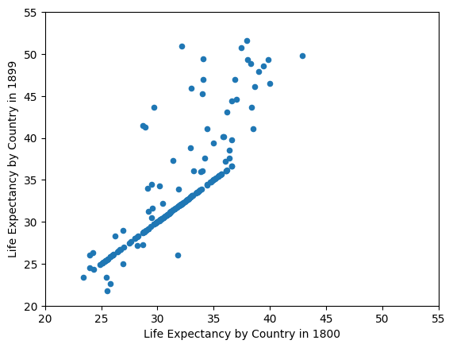

**Gapminder Life Expectancy**:

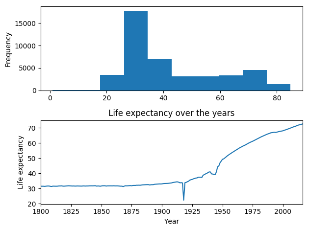